# Datasettøving 1: Hvor rusler reven?

Karin Mollatt og Martine Sørgård Olsen

2022-10-10

*Laster inn datasettet, og nødvendige pakker ved start.*

```r
library(tidyverse)
library(sp)
library(sf)
library(leaflet)

load("foxdata_STIN100.RData")

# Skrur av spherical geometry
sf::sf_use_s2(FALSE)
```

## 3: Lasting og bruk av GPS-data

*Print hvert av disse objektene og beskriv hva dere tror de inneholder.*

```r
# Printer datarammen foxes
foxes
```

```
## Simple feature collection with 1437 features and 2 fields
## Geometry type: POINT
## Dimension:     XY
## Bounding box:  xmin: 10.7299 ymin: 59.66462 xmax: 10.80547 ymax: 59.72753
## Geodetic CRS:  WGS 84
## First 10 features:
##         id            datetime                  geometry
## 1   fox_12 2018-07-27 19:39:05 POINT (10.76165 59.67996)
## 13  fox_12 2018-07-27 19:54:58 POINT (10.75776 59.68188)
## 32  fox_12 2018-07-27 20:11:14   POINT (10.7572 59.6819)
## 52  fox_12 2018-07-27 20:27:44 POINT (10.75909 59.67982)
## 60  fox_12 2018-07-27 20:44:58 POINT (10.76167 59.67992)
## 63  fox_12 2018-07-27 22:07:11 POINT (10.76647 59.67733)
## 82  fox_12 2018-07-27 22:23:39 POINT (10.76485 59.67812)
## 100 fox_12 2018-07-27 22:40:14 POINT (10.76488 59.67868)
## 117 fox_12 2018-07-28 00:02:45 POINT (10.77529 59.68305)
## 130 fox_12 2018-07-28 00:35:12 POINT (10.77572 59.68445)
```

```r
# Printer de unike IDene til revene
unique(foxes$id)
```

```
## [1] fox_12 fox_13 fox_14 fox_16 fox_6  fox_7  fox_9
## Levels: fox_12 fox_13 fox_14 fox_16 fox_6 fox_7 fox_9
```

Datarammen *foxes* inneholder GPS-observasjoner av sju ulike rever. Den har tre variabler: `id`, `datetime` og `geometry`.

- `id`: Nummer på hvilken rev det er, i den rekkefølgen de ble merket.
- `datetime`: Dato og tid for observasjonen
- `geometry`: Koordinater for observasjonen

```r
# Printer datarammen fox7
fox7
```

```
## Simple feature collection with 3687 features and 4 fields
## Geometry type: POINT
## Dimension:     XY
## Bounding box:  xmin: 10.74113 ymin: 59.66451 xmax: 10.78857 ymax: 59.68354
## Geodetic CRS:  WGS 84
## First 10 features:
##         id            datetime n.sats battery.pcnt                  geometry
## 4229 fox_7 2018-02-10 11:30:13      7           86  POINT (10.76859 59.6795)
## 4228 fox_7 2018-02-10 11:36:16     11           85  POINT (10.76864 59.6795)
## 4227 fox_7 2018-02-10 11:36:31     10           85 POINT (10.76856 59.67949)
## 4226 fox_7 2018-02-10 11:36:46     11           85 POINT (10.76845 59.67944)
## 4225 fox_7 2018-02-10 11:37:01     11           85 POINT (10.76847 59.67945)
## 4224 fox_7 2018-02-10 11:37:16     11           85 POINT (10.76848 59.67947)
## 4223 fox_7 2018-02-10 11:37:30     10           85  POINT (10.7685 59.67948)
## 4222 fox_7 2018-02-10 11:37:45     11           85 POINT (10.76849 59.67947)
## 4221 fox_7 2018-02-10 11:38:00     11           85  POINT (10.7685 59.67947)
## 4220 fox_7 2018-02-10 11:38:15     10           85 POINT (10.76849 59.67947)
```

Datarammen *fox7* inneholder hyppigere GPS-observasjoner av rev nummer 7 - [Lucky Number Slevin](https://en.wikipedia.org/wiki/Lucky_Number_Slevin). Den har fem variabler: `id`, `datetime`, `n.sats`, `battery.pcnt` og `geometry`. De variablene som er ulike fra *foxes*-datarammen er:

- `n.sats`: Denne variabelen inneholder verdiene fra 4 til 14 i denne datarammen. Uten noen videre informasjon har vi ikke nok kunnskap om datasettet til å konkludere hva variabelen beskriver.
- `battery.pcnt`: Batteriprosent på GPS-halsbåndet

```r
# Printer datarammen fox7.utm
fox7.utm
```

```
## Simple feature collection with 3687 features and 4 fields
## Geometry type: POINT
## Dimension:     XY
## Bounding box:  xmin: 1215314 ymin: 6626737 xmax: 1217902 ymax: 6628977
## CRS:           +proj=tmerc +lat_0=0 +lon_0=15.8000000000016 +k=1 +x_0=1500000 +y_0=0 +ellps=bessel +towgs84=414.1,41.3,603.1,-0.855,2.141,-7.023,0 +units=m +no_defs
## First 10 features:
##         id            datetime n.sats battery.pcnt                geometry
## 4229 fox_7 2018-02-10 11:30:13      7           86 POINT (1216890 6628475)
## 4228 fox_7 2018-02-10 11:36:16     11           85 POINT (1216892 6628474)
## 4227 fox_7 2018-02-10 11:36:31     10           85 POINT (1216888 6628474)
## 4226 fox_7 2018-02-10 11:36:46     11           85 POINT (1216881 6628469)
## 4225 fox_7 2018-02-10 11:37:01     11           85 POINT (1216882 6628469)
## 4224 fox_7 2018-02-10 11:37:16     11           85 POINT (1216883 6628471)
## 4223 fox_7 2018-02-10 11:37:30     10           85 POINT (1216884 6628472)
## 4222 fox_7 2018-02-10 11:37:45     11           85 POINT (1216884 6628472)
## 4221 fox_7 2018-02-10 11:38:00     11           85 POINT (1216884 6628471)
## 4220 fox_7 2018-02-10 11:38:15     10           85 POINT (1216884 6628472)
```

Datarammen *fox7.utm* er identisk som *fox7* utenom variabelen `geometry`. Forskjellen er at GPS-punktet i denne datarammen er angitt ved UTM-koordinater, mens GPS-punktet i datarammen *foxes* er angitt ved lengde- og breddegrader Kilde: UTM (Lest 10.10.2022)

```r
# Printer datarammen ar5
ar5
```

```
## Simple feature collection with 4959 features and 4 fields
## Geometry type: MULTIPOLYGON
## Dimension:     XY
## Bounding box:  xmin: 10.70939 ymin: 59.65327 xmax: 10.82599 ymax: 59.73936
## Geodetic CRS:  WGS 84
## First 10 features:
##       artype artreslag artype_artreslag  coarse.type
## 23685     30        32            30-32       forest
## 23690     50        39            50-39 crop.pasture
## 23701     81        98            81-98        water
## 23713     30        33            30-33       forest
## 23716     50        39            50-39 crop.pasture
## 23719     12        98            12-98         road
## 23721     12        98            12-98         road
## 23722     12        98            12-98         road
## 23739     50        39            50-39 crop.pasture
## 23751     81        98            81-98        water
##                             geometry
## 23685 MULTIPOLYGON (((10.72427 59...
## 23690 MULTIPOLYGON (((10.72165 59...
## 23701 MULTIPOLYGON (((10.73864 59...
## 23713 MULTIPOLYGON (((10.71677 59...
## 23716 MULTIPOLYGON (((10.72158 59...
## 23719 MULTIPOLYGON (((10.73732 59...
## 23721 MULTIPOLYGON (((10.71226 59...
## 23722 MULTIPOLYGON (((10.72577 59...
## 23739 MULTIPOLYGON (((10.71767 59...
## 23751 MULTIPOLYGON (((10.73706 59...
```

Datarammen *ar5* er et arealressurskart for området, som kan brukes som en bakgrunn når vi plotter observasjonene. Den inneholder variablene: `artype`, `artreslag`, `artype_artreslag`, `coarse.type` og `geometry`.

- `artype`: Arealtypen i siffer i området (f.eks: 30 (forest), 12 (road) , 81 (water))
- `artreslag`: Type treslag i siffer i området (f.eks: 32, 39, 98)
- `artype_artreslag`: Kombinasjon av `artype` og `artreslag` delt av bindestrek (f.eks: 30-32, 50-39)
- `coarse.type`: Arealtypen i området (f.eks: forest, road, water)
- `geometry`: Koordinater for observasjonen

### 3.1: En nærmere titt på `foxes` med `library(leaflet)`

```r
# Lag en funksjon som oversetter reve-navn til farge.
pal <- colorFactor(palette = "Set1", domain = foxes$id)

foxes %>%                             # Ta reveposisjonene, og:
  leaflet %>%                         # Lag interaktivt kart
  addTiles %>%                        # Legg på grunnslagskart
  addCircleMarkers(color = ~pal(id))  # Legg på posisjonsmerker farget etter rev
```

[interactive chart not shown]

### 3.2: Romlige data i library(sf)

Et romlig objekt er i dette tilfellet punktene vi ser på kartet. Det vil si hver enkelt GPS-observasjon av revene.

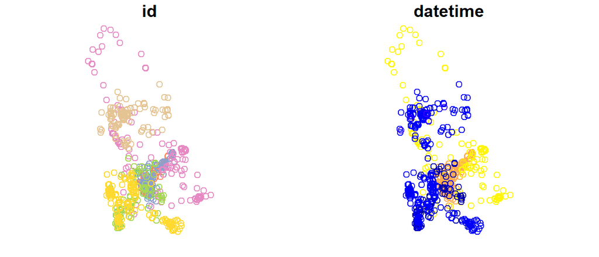

```r
# Ser på hele datasettet
plot(foxes)
```

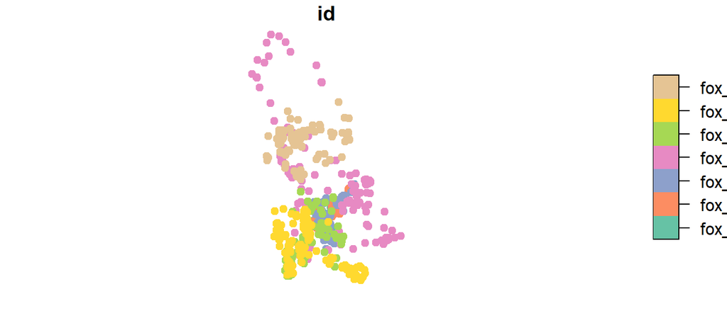

```r
# Ser på kun én attributt
plot(foxes["id"], pch = 19)
```

### 3.3: Koordinatsystemer og plotting av romlige objekter

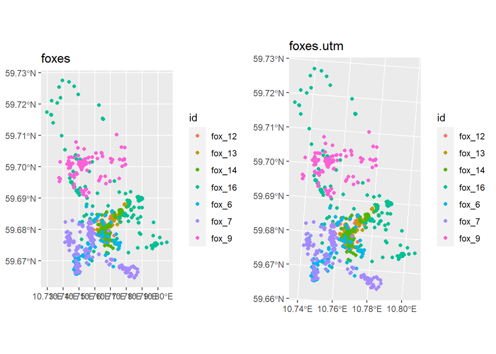

```r
# Lagrer plottene i hver sin variabel
foxes_plot <- ggplot(foxes, aes(colour = id)) +
  geom_sf() +
  ggtitle("foxes")
foxes_utm_plot <- ggplot(foxes.utm, aes(colour = id)) +
  geom_sf() +
  ggtitle("foxes.utm")

# Legger plottene ved siden av hverandre, for å enklere kunne sammenlikne
# Kode sterkt inspirert fra: https://stackoverflow.com/questions/1249548/side-by-side-plots-with-ggplot2
gridExtra::grid.arrange(foxes_plot, foxes_utm_plot, ncol=2)
```

Vi ser at de to plottene inneholder nøyaktig samme observasjonspunkter, slik som antatt. Derimot er koordinatsystemet ulikt, fordi `geometry`-variabelen er forskjellig i datarammene.

`geometri` i *foxes* er oppgitt i lengde- og breddegrader og derfor er koordinatssystemet tilnærmet rett. Plottet av *foxes.utm* har færre merker på x-aksen, som vil si at rutene i koordinatsystemet er større. Årsaken til dette er at geometrien er oppgitt som UTM-koordinater, og dette går ut på at du forsøker å lage et 2D kart av en jordklode (som er i 3D).

## 5 Analyse av hjemmeområder og habitatseleksjon

```r
# vi velger her å ikke vise meldinger og advarsler, for en ryddigere rapport.

foxes.mcp <- foxes.utm %>%
  # mcp() forventer bare én attributt, nemlig individ-id
  dplyr::select("id") %>%
  # Konverter til gammeldags objekttype som mcp() trenger
  as("Spatial") %>%
  adehabitatHR::mcp(percent = 95) %>%
  # Konverter tilbake til sf, som funker bedre med dplyr
  st_as_sf %>%
  # Transformer til samme koordinatsystem som `foxes`
  st_transform(st_crs(foxes))

foxes.mcp %>%
  leaflet %>%
  addTiles %>%
  addPolygons(color = ~pal(id), weight=1, fillOpacity = 0.3) %>%
  addCircleMarkers(data = foxes, color = ~pal(id), weight = 2, radius = 7) %>%
  addLegend(pal = pal, values = ~id)
```

[interactive chart not shown]

```r
# Sorterer alle rader i kolonnen area etter størrelse
sort_foxes <- foxes.mcp[order(foxes.mcp$area),]
sort_foxes
```

```
## Simple feature collection with 7 features and 2 fields
## Geometry type: POLYGON
## Dimension:     XY
## Bounding box:  xmin: 10.73491 ymin: 59.66633 xmax: 10.80787 ymax: 59.7202
## Geodetic CRS:  WGS 84
##            id       area                       geometry
## fox_12 fox_12   52.46121 POLYGON ((10.77281 59.6841,...
## fox_13 fox_13   55.55999 POLYGON ((10.77895 59.68524...
## fox_14 fox_14  124.12813 POLYGON ((10.78538 59.6869,...
## fox_6   fox_6  270.78230 POLYGON ((10.77865 59.67632...
## fox_9   fox_9  280.13823 POLYGON ((10.77817 59.7029,...
## fox_7   fox_7  328.63904 POLYGON ((10.77103 59.68009...
## fox_16 fox_16 1266.54596 POLYGON ((10.76509 59.7202,...
```

I følge [Store Norske Leksikon](https://snl.no/hjemmeomr%C3%A5de), er hjemmeområdet til et dyr et begrenset område som den selv eller familien anvender jevnlig.

Fra outputen ser vi at `fox_12` (rød) har minst hjemmeområde og `fox_16` (lilla) har størst hjemmeområde.

```r
# Fjerner advarsler i rapporten, for et ryddigere utseende.

foxes.mcp_90 <- foxes.utm %>%
  # mcp() forventer bare én attributt, nemlig individ-id
  dplyr::select("id") %>%
  # Konverter til gammeldags objekttype som mcp() trenger
  as("Spatial") %>%
  adehabitatHR::mcp(percent = 90) %>%
  # Konverter tilbake til sf, som funker bedre med dplyr
  st_as_sf %>%
  # Transformer til samme koordinatsystem som `foxes`
  st_transform(st_crs(foxes))

foxes.mcp_90 %>%
  leaflet %>%
  addTiles %>%
  addPolygons(color = ~pal(id), weight=1, fillOpacity = 0.3) %>%
  addCircleMarkers(data = foxes, color = ~pal(id), weight = 2, radius = 7) %>%
  addLegend(pal = pal, values = ~id)
```

[interactive chart not shown]

Det lilla området som tilhører `fox_16` har synlig blitt mindre, ved å senke “minste konvekse polygon” (MCP) til 90%. Det gjør at estimatet er mindre følsomt for uteliggere (outliers) enn tidligere.

Videre har det brune området som tilhører `fox_9` blitt litt mindre, men det er bare synlig fordi området kun sammenfaller med det lilla hjemmeområdet til `fox_16`.

Resten av områdene overlappes i stor grad av hverandre, som gjør det vanskelig å se med det blotte øyet om hjemmeområdet har endret størrelse. Det vi kan anta er at de fleste hjemmeområdene er litt mindre ved 90% enn ved 95%, fordi følsomheten er lavere. Likevel er det mengden uteliggere blant observasjonene som bestemmer om området minskes inn eller ikke.

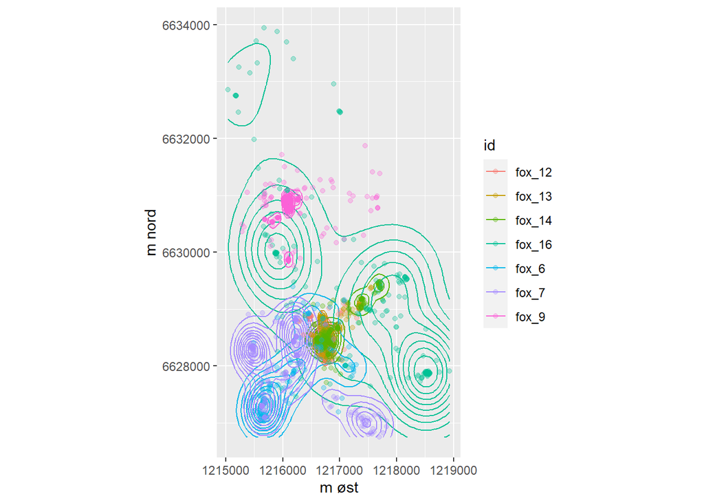

```r
foxes.utm %>%
  bind_cols(foxes.utm %>%
              st_coordinates %>%
              as.data.frame %>%
              set_names(c("m øst", "m nord"))) %>%
  ggplot(aes(x = `m øst`, y = `m nord`, color = id)) +
  geom_density_2d(contour_var = "ndensity") +
  geom_point(alpha = 0.3) +
  coord_equal()
```

### 5.1 Lasting av habitatdata og kobling til GPS-posisjon

```r
# vi velger her å ikke vise meldinger og advarsler, for en ryddigere rapport.

fox13.mcp <- fox13.utm %>%
  # mcp() forventer bare én attributt, nemlig individ-id
  dplyr::select("id") %>%
  # Konverter til gammeldags objekttype som mcp() trenger
  as("Spatial") %>%
  adehabitatHR::mcp(percent = 95) %>%
  # Konverter tilbake til sf, som funker bedre med dplyr
  st_as_sf %>%
  # Transformer til samme koordinatsystem som `fox13`
  st_transform(st_crs(fox13))

fox13.mcp %>%
  leaflet %>%
  addTiles %>%
  addPolygons(color = ~pal(id), weight=1, fillOpacity = 0.3) %>%
  addCircleMarkers(data = fox13, color = ~pal(id), weight = 2, radius = 7) %>%
  addLegend(pal = pal, values = ~id)
```

[interactive chart not shown]

`fox_13` er markert i blå og den oppholder seg for det meste mellom Ås gård (langs Syverudveien) og Hundeskolen Veiviseren på Norderås (nordøst for Norderåsbekken). Samtidig dekker hjemmeområdet også noe nordøst for hundeskolen opp mot krysset mellom Kongeveien og Slørstadveien.

Dette hjemmeområdet består i hovedsak av åkre, men også noe skog, vei, bebygget område og en bekk. I tillegg er det kun noen kilometer nord for campus, så her er det muligheter for å se rev på en sen søndagstur!

### 5.2 Hvordan varierer habitatbruken til hver rev gjennom døgnet?

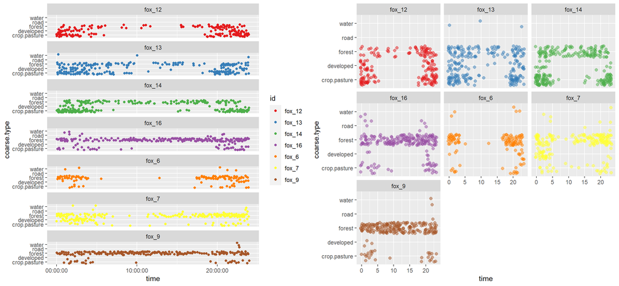

```r
# Finner habitat for hver GPS-posisjon
foxes.hab <- st_intersection(foxes, ar5)

# Lager en ny kolonne som inneholder time, og lagrer det i en ny dataramme
# for hvert plott
foxes.lubri.time <- foxes.hab %>%
  mutate(time = lubridate::hour(datetime))

foxes.hms.time <- foxes.hab %>%
  mutate(time = hms::as_hms(datetime))

# Beholder fargene som er brukt tidligere
# Kode sterkt inspirert fra: https://www.statology.org/color-by-factor-ggplot2/
library(RColorBrewer)
myColors_foxes <- brewer.pal(n = length(levels(foxes$id)),
                             name = "Set1")
names(myColors_foxes) <- levels(foxes$id)
custom_colors_foxes <- scale_colour_manual(name = "id",
                                           values = myColors_foxes)

# Lagrer de to plottene til en variabel som vi kan hente senere
hab.use1 <- ggplot(data = foxes.hms.time,
                   mapping = aes(x = time,
                                 y = coarse.type,
                                 color = id,
                                 group = id)) +
  geom_jitter() +
  # Vi vil se på hver rev, og "wrapper" derfor med hensyn på `id`
  facet_wrap(facets = vars(id),
             ncol = 1,
             # Antall rader blir lik antall rever i datarammen
             # Her kunne man også bare skrevet nrow = 7, men denne koden
             # er mer generell.
             nrow = length(levels(foxes.hms.time$id))) +
  custom_colors_foxes

hab.use2 <- ggplot(data = foxes.lubri.time,
                   mapping = aes(x = time,
                                 y = coarse.type,
                                 color = id,
                                 group = id)) +
  # Gjør punktene gjennomsiktige, og regulerer størrelsen.
  # Fjerner legend til plottet til høyre, fordi den følger samme fargekoder
  # som plottet til venstre.
  geom_jitter(alpha = 0.5, size = 2, show.legend = FALSE) +
  facet_wrap(facets = vars(id)) +
  custom_colors_foxes

# Legger plottene ved siden av hverandre
gridExtra::grid.arrange(hab.use1, hab.use2, ncol=2)
```

På plottene kan man se at habitatbruken til `fox_7` er noe spredt mellom hovedsakelig skog, bebygget område og åkre.

### 5.3 Foretrekker reven noen leveområder fremfor andre?

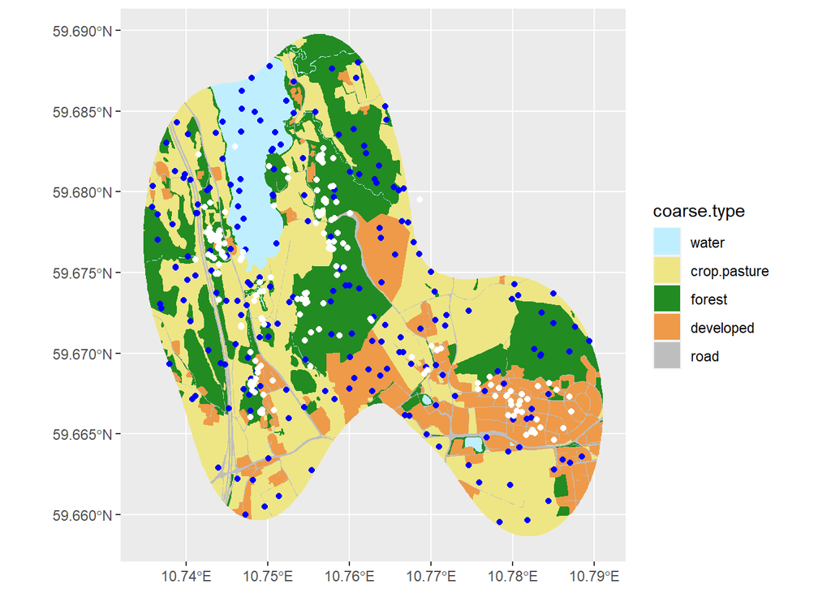

```r
# Skaffer polygonet som angir 95% kernel home range.
fox <- foxes.hab %>% filter(id == "fox_7")
fox.vert <- adehabitatHR::getverticeshr(ud$fox_7, percent = 95) %>%
  st_as_sf

# Null-modell-tilnærming

# Trekker først en tilfeldig observasjon av rev 7
random <- st_sample(fox.vert, nrow(fox))
# Dette er foreløpig et såkalt "Geometry set", dvs bare punkter uten "attributer" (egenskaper). For å kunne gi egenskaper til punktene, må vi lage
# en "Simple feature collection" med st_sf().
# Dessuten gir vi den en id-kolonne så vi senere kan skille den fra `fox`
# ovenfor, og så slår vi opp habitattype for hvert punkt med st_intersection, som over.
random <- st_sf(geometry = random, id = "random", stringsAsFactors = FALSE) %>%
  st_intersection(ar5)

# Klipp ut den delen av arealressurskartet som overlapper med hjemmeområdet
ar5.small <- st_intersection(fox.vert, ar5)

# R colour cheat sheet:
# https://www.nceas.ucsb.edu/~frazier/RSpatialGuides/colorPaletteCheatsheet.pdf
fargeskala <- c(
  "water" = "lightblue1",
  "crop.pasture" = "khaki2",
  "forest" = "forestgreen",
  "developed" = "tan2",
  "road" = "grey"
)

# Lagene plottes i den rekkefølgen de angis, så vi legger arealressurskartet i bunn
ggplot() +
  geom_sf(data = ar5.small, mapping = aes(fill = coarse.type), colour = NA) +
  geom_sf(data = random, colour = "blue") +
  geom_sf(data = fox, colour = "white") +
  scale_fill_manual(values = fargeskala)
```

```r
# Teller opp antall punkter i hver habitattype, separat for ekte og simulerte punkter
begge <- bind_rows(as_tibble(fox), as_tibble(random))
table(begge$id, begge$coarse.type)
```

```
##
##          crop.pasture developed forest road water
##   fox_7            28        35    138    5     3
##   random           75        33     70   11    20
```

```r
begge %>%
  count(id, coarse.type) %>%
  spread(coarse.type, n)
```

```
## # A tibble: 2 × 6
##   id     crop.pasture developed forest  road water
##   <chr>         <int>     <int>  <int> <int> <int>
## 1 fox_7            28        35    138     5     3
## 2 random           75        33     70    11    20
```

Habitatseleksjon er definert som “*hvor mye et habitat blir brukt i forhold til hvor tilgjengelig det er*” av Sam Perrin ved [Ecology for the Masses](https://ecologyforthemasses.com/2019/05/14/hvorfor-er-dyr-hvor-de-er/).

Tallene over forteller oss at rev 7 velger å oppholde seg for det meste i skog, på åkre og i bebygget område. Denne kombinasjonen passer fint med en hypotese om at den sover i skogen, jakter på åkre og finner søppel den kan spise i bebygget område.

Likevel kan man legge merke til at det er flere observasjoner i bebygget område enn det er på åkre. Dette kan tyde på at reven får en større del av kostholdet sitt fra søppel eller lignende fra oss mennesker, fordi det er lett tilgjengelig.

### 5.4 I revens fotspor på NMBU: visualisering av romlige data i Google Earth eller Google Maps

```r
# Konvertere fox7 fra en samling punkter til en LINESTRING simple feature
# https://github.com/r-spatial/sf/issues/692#issuecomment-377671101
fox7.line <- fox7 %>%
  summarise(do_union = FALSE) %>%
  st_cast("LINESTRING")
# Må også konvertere til gammeldags sp-objekt istedenfor sf
fox7.line %>%
  as("Spatial") %>%
  plotKML::kml(file.name = "fox7.kml",
               colour = "orange",
               shape = 'http://maps.google.com/mapfiles/kml/pal2/icon18.png',
               size = 0.3)

# Konvertere fox12 fra en samling punkter til en LINESTRING simple feature
# https://github.com/r-spatial/sf/issues/692#issuecomment-377671101
fox12.line <- fox12 %>%
  summarise(do_union = FALSE) %>%
  st_cast("LINESTRING")
# Må også konvertere til gammeldags sp-objekt istedenfor sf
fox12.line %>%
  as("Spatial") %>%
  plotKML::kml(file.name = "fox12.kml",
               colour = "orange",
               shape = 'http://maps.google.com/mapfiles/kml/pal2/icon18.png',
               size = 0.3)

# Konvertere fox13 fra en samling punkter til en LINESTRING simple feature
# https://github.com/r-spatial/sf/issues/692#issuecomment-377671101
fox13.line <- fox13 %>%
  summarise(do_union = FALSE) %>%
  st_cast("LINESTRING")
# Må også konvertere til gammeldags sp-objekt istedenfor sf
fox13.line %>%
  as("Spatial") %>%
  plotKML::kml(file.name = "fox13.kml",
               colour = "orange",
               shape = 'http://maps.google.com/mapfiles/kml/pal2/icon18.png',
               size = 0.3)

# Konvertere fox14 fra en samling punkter til en LINESTRING simple feature
# https://github.com/r-spatial/sf/issues/692#issuecomment-377671101
fox14.line <- fox14 %>%
  summarise(do_union = FALSE) %>%
  st_cast("LINESTRING")
# Må også konvertere til gammeldags sp-objekt istedenfor sf
fox14.line %>%
  as("Spatial") %>%
  plotKML::kml(file.name = "fox14.kml",
               colour = "orange",
               shape = 'http://maps.google.com/mapfiles/kml/pal2/icon18.png',
               size = 0.3)
```

#### Kart

Under ligger linker til Google Maps-kart som inneholder sporene til de utvalgte revene. Det andre kartet inneholder spor til 3 rever som ligger i lag, og du kan derfor velge å skjule disse lagene om du kun vil se på en av de.

[Kart over sporet til rev 7 i Ås og omegn i februar 2018](https://www.google.com/maps/d/edit?mid=1bgfj2LF3-nw_qdpiggdRRaQRMe7xOoM&usp=sharing)

[Kart over sporene til rev 12, 13 og 14 i Ås og omegn](https://www.google.com/maps/d/edit?mid=1L5bVp3EHhRSGtCSMrs-cE6l5pJJpXjI&usp=sharing)

På kartet til de unge søskenrevene 12, 13 og 14 kan man se at de oppholder seg mest i området rundt Norderåsbekken, nord for Ås gård og sør for Hundeskolen Veiviseren. Dette området er en blanding av skog, bebygget område og åker. Som tidligere nevnt tror vi årsaken til dette er fordi revene kan beskytte og gjemme seg i skogen. Videre kan de nok jakte både på åkrene og i skogen, men at de også finner mat blant søppel som vi mennesker etterlater oss lett tilgjengelig i bebygde områder.